# Exploratory data analysis

## 1 Preparing the data

We will first read the file into a dataframe specially taking care of quotes and separators.  
Following that we print a sample of our dataset for better understanding.

```r
ted_talks <- read.table(file="/Volumes/SD/GoogleDrive/0.DA/Assignments/1/ted.csv",
                        header=TRUE, sep=";", fill = TRUE, quote="\"")
head(ted_talks)
```

```
##   X...comments                                          name duration
## 1         4553     Ken Robinson: Do schools kill creativity?     1164
## 2          265          Al Gore: Averting the climate crisis      977
## 3          124                 David Pogue: Simplicity sells     1286
## 4          200            Majora Carter: Greening the ghetto     1116
## 5          593 Hans Rosling: The best stats you've ever seen     1190
## 6          672            Tony Robbins: Why we do what we do     1305
##     event  film_date published_date languages num_speaker    views
## 1 TED2006 1140825600     1151367060        60           1 47227110
## 2 TED2006 1140825600     1151367060        43           1  3200520
## 3 TED2006 1140739200     1151367060        26           1  1636292
## 4 TED2006 1140912000     1151367060        35           1  1697550
## 5 TED2006 1140566400     1151440680        48           1 12005869
## 6 TED2006 1138838400     1151440680        36           1 20685401
```

We noticed that the film date and published date were stored in the POSIXct format which is not very informative.  
To solve that problem we will extract a proper date and add new columns (features) representing the day, month and year of the date.

```r
require(anytime)
require(data.table)

ted_talks$film_date = anydate(ted_talks$film_date)
ted_talks$film_day = weekdays(ted_talks$film_date,abbreviate = TRUE) #gives the day
ted_talks$film_month = month(ted_talks$film_date) #gives the month
ted_talks$film_year = year(ted_talks$film_date) #gives the year

ted_talks$published_date = anydate(ted_talks$published_date)
ted_talks$published_day = weekdays(ted_talks$published_date,abbreviate = TRUE) #gives the day
ted_talks$published_month = month(ted_talks$published_date) #gives the month
ted_talks$published_year = year(ted_talks$published_date) #gives the year
```

This time to understand the data types of our columns we will plot the column names with their data types and sample values:

```r
str(ted_talks)
```

```
## 'data.frame':    2549 obs. of  15 variables:
##  $ X...comments   : int  4553 265 124 200 593 672 919 46 852 900 ...
##  $ name           : Factor w/ 2549 levels "AJ Jacobs: How healthy living nearly killed me",..: 1334 41 607 1482 915 2438 1267 1244 513 1990 ...
##  $ duration       : int  1164 977 1286 1116 1190 1305 992 1198 1485 1262 ...
##  $ event          : Factor w/ 355 levels "AORN Congress",..: 57 57 57 57 57 57 57 57 57 57 ...
##  $ film_date      : Date, format: "2006-02-25" "2006-02-25" ...
##  $ published_date : Date, format: "2006-06-27" "2006-06-27" ...
##  $ languages      : int  60 43 26 35 48 36 31 19 32 31 ...
##  $ num_speaker    : int  1 1 1 1 1 1 1 1 1 1 ...
##  $ views          : int  47227110 3200520 1636292 1697550 12005869 20685401 3769987 967741 2567958 3095993 ...
##  $ film_day       : chr  "Sat" "Sat" "Fri" "Sun" ...
##  $ film_month     : int  2 2 2 2 2 2 2 2 2 2 ...
##  $ film_year      : int  2006 2006 2006 2006 2006 2006 2006 2006 2006 2006 ...
##  $ published_day  : chr  "Tue" "Tue" "Tue" "Tue" ...
##  $ published_month: int  6 6 6 6 6 6 7 7 7 7 ...
##  $ published_year : int  2006 2006 2006 2006 2006 2006 2006 2006 2006 2006 ...
```

We can observe that new date columns add very useful extra information.  
Also we can see that all columns seem to be stored in proper formats.

## 2 Investigating individual variables

### Summary of data

First we will take a high level overview by finding Minimal, Maximal, Mean, Median, 1st Quartile and 3rd Quartile values for all (numeric and date) columns using the summary function. This will not be very helpful for character columns.

```r
summary(ted_talks)
```

```
##   X...comments
##  Min.   :   2.0
##  1st Qu.:  63.0
##  Median : 118.0
##  Mean   : 191.6
##  3rd Qu.: 222.0
##  Max.   :6404.0
##
##                                                                    name
##  AJ Jacobs: How healthy living nearly killed me                      :   1
##  AJ Jacobs: My year of living biblically                             :   1
##  AJ Jacobs: The world's largest family reunion ... we're all invited!:   1
##  Aakash Odedra: A dance in a hurricane of paper; wind and light      :   1
##  Aala El-Khani: What it's like to be a parent in a war zone          :   1
##  Aaron Huey: America's native prisoners of war                       :   1
##  (Other)                                                             :2543
##     duration          event        film_date          published_date
##  Min.   : 135.0   TED2014:  84   Min.   :1972-05-14   Min.   :1970-01-01
##  1st Qu.: 577.0   TED2009:  83   1st Qu.:2009-11-06   1st Qu.:2010-03-12
##  Median : 848.0   TED2013:  77   Median :2012-04-02   Median :2012-06-28
##  Mean   : 826.8   TED2016:  77   Mean   :2011-11-22   Mean   :2012-07-22
##  3rd Qu.:1047.0   TED2015:  75   3rd Qu.:2014-10-11   3rd Qu.:2015-02-06
##  Max.   :5256.0   TED2011:  70   Max.   :2017-08-27   Max.   :2017-09-22
##                   (Other):2083
##    languages       num_speaker           views            film_day
##  Min.   :  0.00   Min.   :    1.00   Min.   :   50443   Length:2549
##  1st Qu.: 23.00   1st Qu.:    1.00   1st Qu.:  755399   Class :character
##  Median : 28.00   Median :    1.00   Median : 1123955   Mode  :character
##  Mean   : 27.69   Mean   :   41.04   Mean   : 1698338
##  3rd Qu.: 33.00   3rd Qu.:    1.00   3rd Qu.: 1701743
##  Max.   :999.00   Max.   :99999.00   Max.   :47227110
##                   NA's   :25
##    film_month       film_year    published_day      published_month
##  Min.   : 1.000   Min.   :1972   Length:2549        Min.   : 1.000
##  1st Qu.: 3.000   1st Qu.:2009   Class :character   1st Qu.: 3.000
##  Median : 5.000   Median :2012   Mode  :character   Median : 6.000
##  Mean   : 5.662   Mean   :2011                      Mean   : 6.299
##  3rd Qu.: 9.000   3rd Qu.:2014                      3rd Qu.: 9.000
##  Max.   :12.000   Max.   :2017                      Max.   :12.000
##
##  published_year
##  Min.   :1970
##  1st Qu.:2010
##  Median :2012
##  Mean   :2012
##  3rd Qu.:2015
##  Max.   :2017
##
```

### Plotting a histogram for all numeric columns

Secondly, we will use a very convenient function of ggplot to create histograms of each numeric variable.  
This will help us to identify possible outliers and the distribution of data.

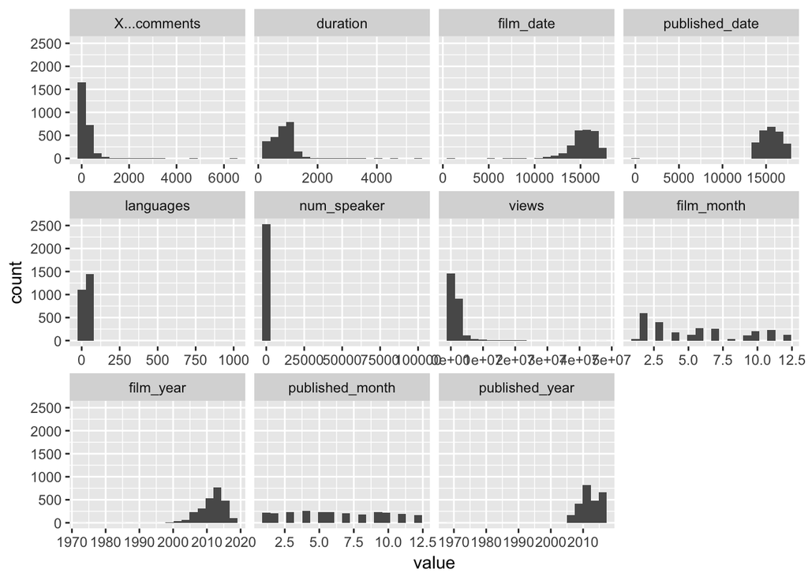

```r
require(ggplot2)
ggplot(data = melt(ted_talks), mapping = aes(x = value)) +
  geom_histogram(bins = 20) + facet_wrap(~variable, scales = 'free_x')
```

### Cleaning numeric data

#### 1.Finding outliers

We will analyze the summary and histograms we just produced.

We can first observe that some numeric columns have easily identifiable outliers. For example the **num_speaker** column has a value of 99999 which I can hardly imagine occuring. Similarly the **languages** column has a value of 999 which is definitely too much.

The **film year, published_year, film_date, published_date** columns have values from 1972 which is quite an extreme since the mean and median values are in the range of 2011 and 2012.

#### 2. Fixing outliers

Lets first see in more details the distribution of dates. Specifically we are fixing these columns **film year, published_year, film_date, published_date**:

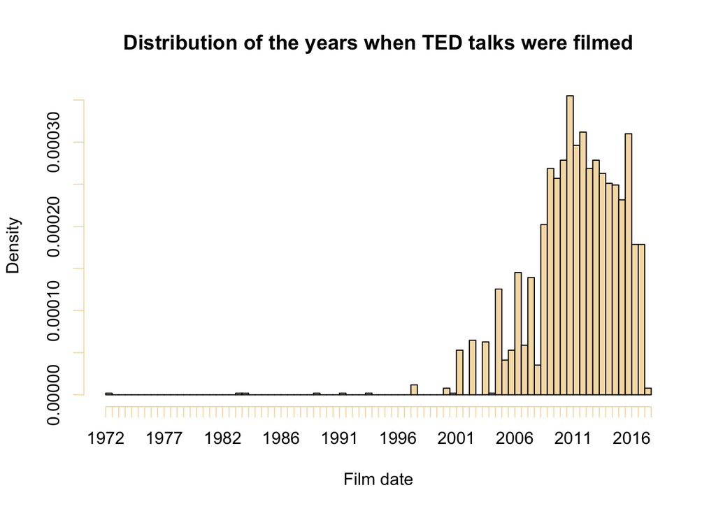

```r
hist(ted_talks$film_date,breaks=100, col="wheat",main="Distribution of the years when TED talks were filmed", xlab = "Film date")
```

Because they are quite rare (and don’t make much sense) we will manually replace the date values that are before 1995 for published and filmed dates (for all 4 columns we mentioned) with the respective medians.

```r
ted_talks$film_date[(ted_talks$film_date< "1995-01-01")] <- median(ted_talks$film_date, na.rm=TRUE)

ted_talks$published_date[(ted_talks$published_date< "1995-01-01")] <- median(ted_talks$published_date, na.rm=TRUE)

ted_talks$film_year[(ted_talks$film_year< 1995)] <- median(ted_talks$film_year, na.rm=TRUE)

ted_talks$published_year[(ted_talks$published_year< 1995)] <- median(ted_talks$published_year, na.rm=TRUE)
```

Lastly we will focus on the **num_speaker** and **languages** columns.

For **num_speaker** column we just have to remove the one outlier with 99999 speakers. I will replace all events with more than 10 speakers with the median of all values.  
For **languages** we will do the same for values above 400.

```r
ted_talks$num_speaker[(ted_talks$num_speaker > 10)] <- median(ted_talks$num_speaker, na.rm=TRUE)

ted_talks$languages[(ted_talks$languages > 400)] <- median(ted_talks$languages, na.rm=TRUE)
```

#### 3. Finding NA values

Let’s now see how many NA values we had in each column:

```r
sapply(ted_talks, function(x) sum(is.na(x)))
```

```
##    X...comments            name        duration           event
##               0               0               0               0
##       film_date  published_date       languages     num_speaker
##               0               0               0              25
##           views        film_day      film_month       film_year
##               0               0               0               0
##   published_day published_month  published_year
##               0               0               0
```

It seems that **num_speaker** column is a bit problematic with regards to missing values.  
Fortunately 25 rows represent a really small proportion of less than 1%.

#### 4. Fixing NA values

We will fill in those values with the respective median value.

```r
ted_talks$num_speaker[is.na(ted_talks$num_speaker)] <- median(ted_talks$num_speaker, na.rm=TRUE)
```

### Cleaning character data

From the summary we can observe that it was not very informative for character columns **name, event, film_day and published_day**. To combat this we will explore them using a barplot.

#### Plotting the distribution of character values

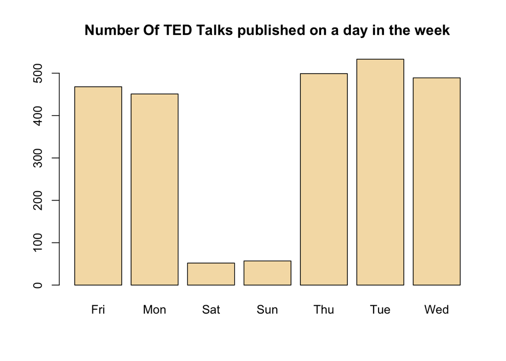

```r
barplot( table(ted_talks$published_day),col = "wheat", main="Number Of TED Talks published on a day in the week")
```

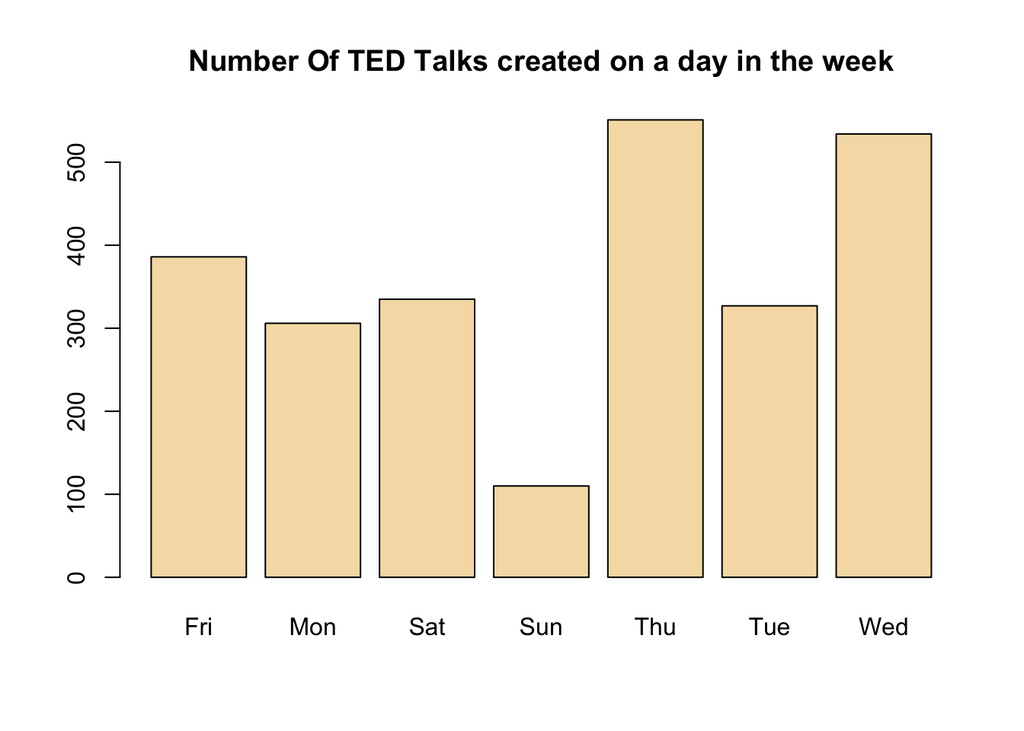

```r
barplot( table(ted_talks$film_day),col = "wheat", main="Number Of TED Talks created on a day in the week")
```

It’s interesting to see that TED talks are created most frequently on Wednesdays and Thursdays and that they are rarely published over the weekend.

Next I believe that it might be useful to add an extra column of how long is the name of the TED talk.  
I will also create a histogram of those lengths.

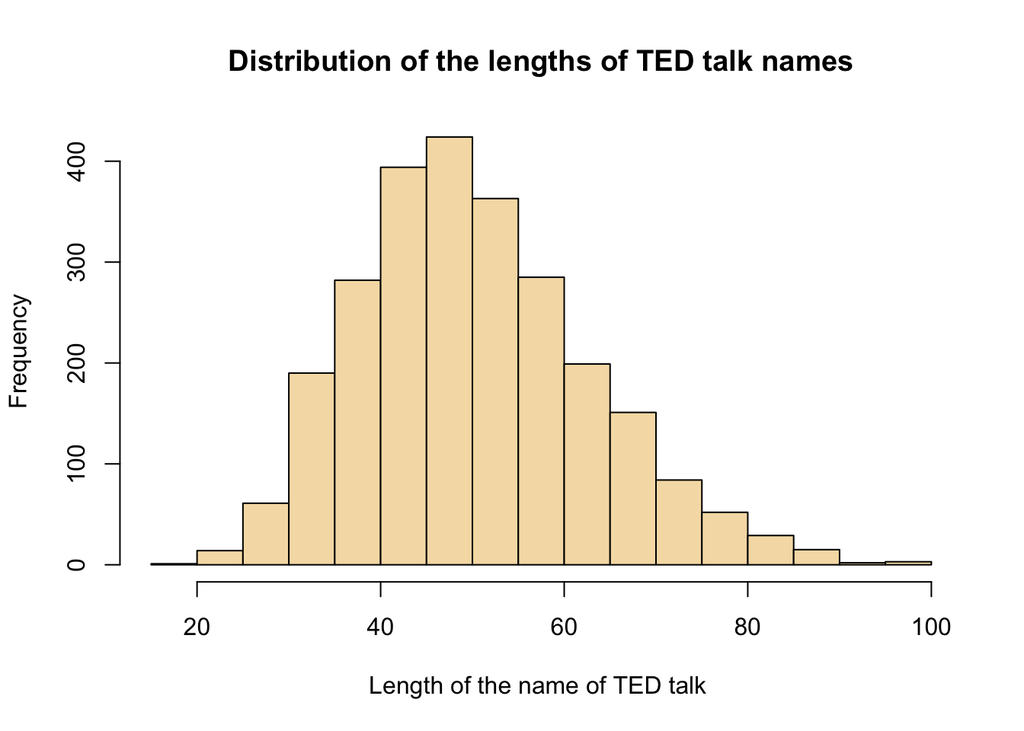

```r
library(stringr)
ted_talks$name_length <- str_count(ted_talks$name)

hist(ted_talks$name_length,col="wheat",main="Distribution of the lengths of TED talk names", xlab="Length of the name of TED talk ")
```

The values in those columns seem pretty normally distributed on a unimodal distribution.

### Basic exploration of the number of views of a talk

We will now explore the distribution of the number of views a talk receives.  
To start of we will use the summary function and then plot a histogram.

```r
summary(ted_talks$views)
```

```
##     Min.  1st Qu.   Median     Mean  3rd Qu.     Max.
##    50443   755399  1123955  1698338  1701743 47227110
```

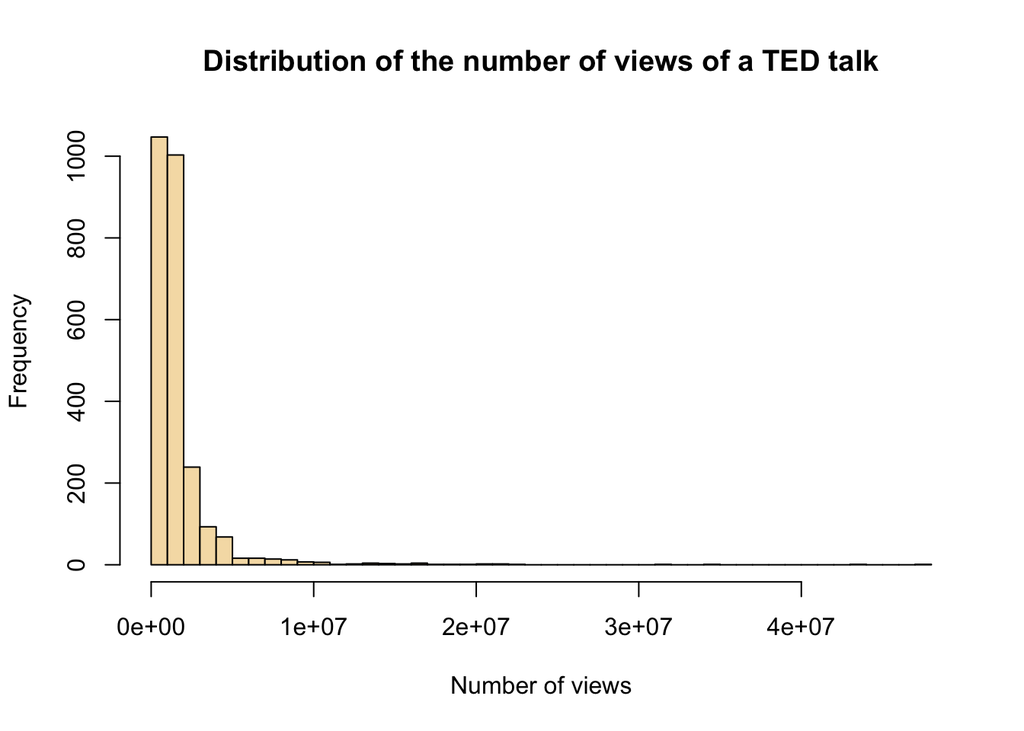

```r
hist(ted_talks$views,breaks=50, col="wheat",main="Distribution of the number of views of a TED talk", xlab = "Number of views")
```

The histogram nicely confirms the initial summary of the distribution of values.  
The mean number of views is around 1 700 000 while the maximum is quite large - 50 million views.  
This is also an outlier which obviously skews the mean value above the median.

## 3 Associations between variables

Now we will now create a chart that shows a scatter plot between two numerical variables together with their correlation.  
To perform this task we will use a very useful library called **PerformanceAnalytics** that plots two numerical variables on a scatter plot as well as calculate their correlation coefficient.  
This provides us a very nice visual view of the variables along with a mathematical measure.

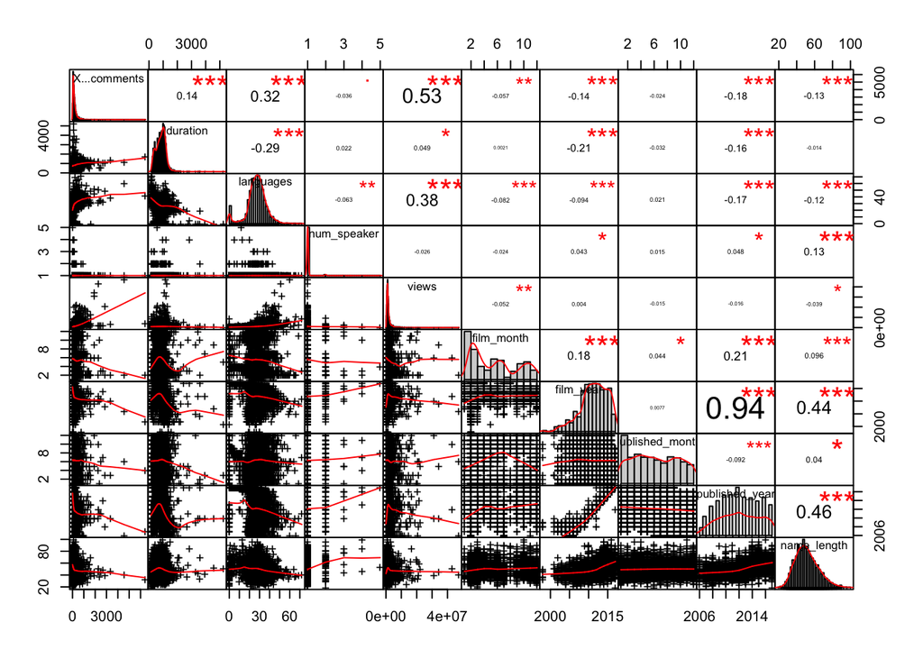

```r
library("PerformanceAnalytics")
suppressWarnings(chart.Correlation(ted_talks[sapply(ted_talks,is.numeric)] , method = "pearson", histogram = TRUE, pch = '+'))
```

Some expected relationships (correlations) we drew from these plots:  
* the number of languages that a talk was translated into is negatively correlated with it’s duration  
* the number of comments is closely correlated with the number of views. The coefficient of 0.53  
* the published year and filmed year are the two most correlated variables (which makes a lot of sense)

## 4 Relationship of variables with the number of views

#### How does the day in the week affect the number of views?

We are now also interested in how the number of views is affected by other variables.  
To start off let’s compare the number of views a TED talk video gets based on the day it’s published and filmed

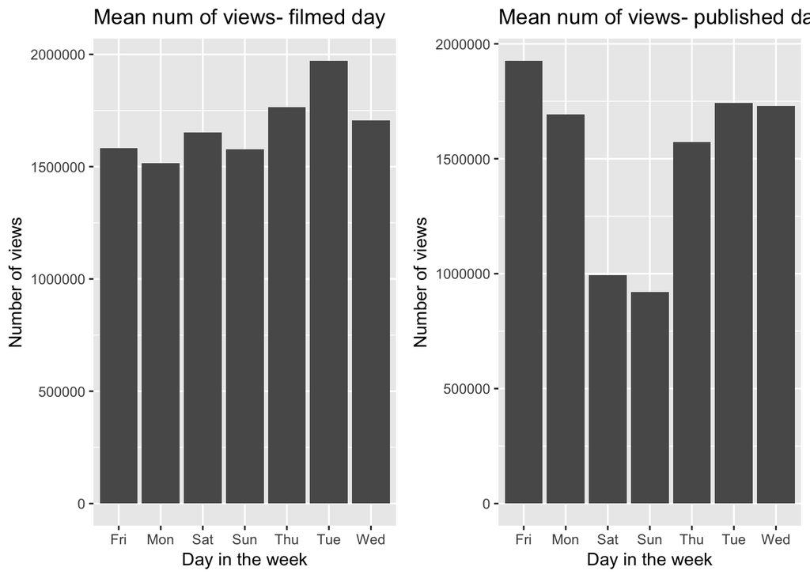

```r
library(gridExtra)
ggplot(ted_talks, aes(x=ted_talks$film_day, y=ted_talks$views))  + stat_summary(fun.y="mean", geom="bar")+ labs(y="Number of views", x = "Day in the week") + ggtitle("Mean num of views- filmed day") -> p1

ggplot(ted_talks, aes(x=ted_talks$published_day, y=ted_talks$views)) + stat_summary(fun.y="mean", geom="bar") + labs(y="Number of views", x = "Day in the week") + ggtitle("Mean num of views- published day") -> p2

grid.arrange(p1, p2, ncol = 2)
```

From this plot we can observe that videos published on weekends (Saturday, Sunday) receive fewer videos.  
But taking into account the previous chart showing that on those days the frequency of publishing videos is very low we must take this fact with a grain of salt.

#### Which events provide the highest number of views?

Now we want to see how the event on which the talk was held has effect on the number of views.  
To do that we first calculate the median number of views TED talks have for that event.  
Then we filter events whose median number of views for all TED talks is two standard deviations higher than the average of the same metric for all events.  
Lastly we plot those events on a barchart ordered by the median number of views a talk received on this event.

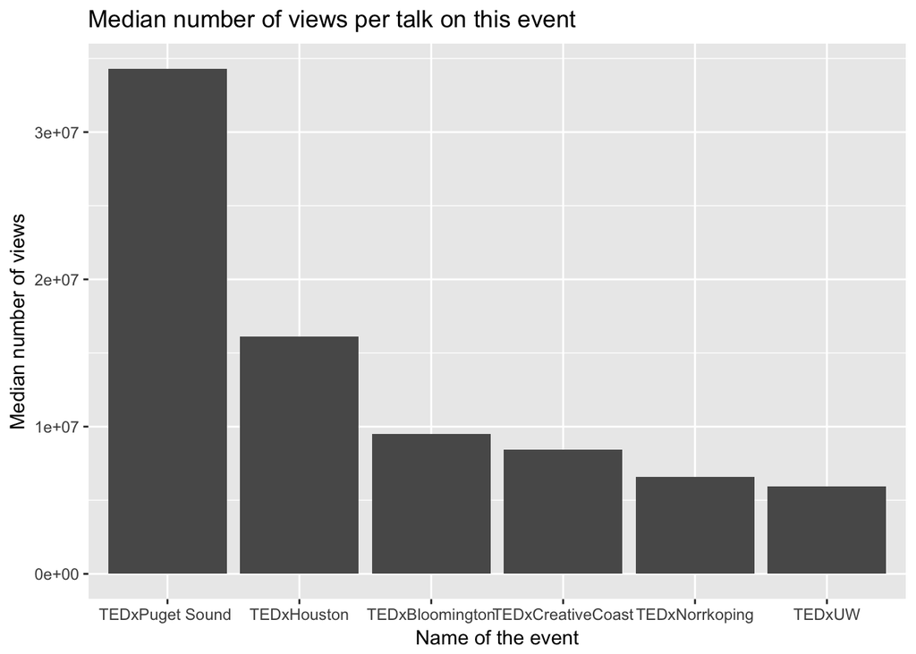

```r
data_raw <- setNames( aggregate(ted_talks$views, list(ted_talks$event), median), c("event", "views"))
p <- data.table(data_raw)
p <- p[,ToKeep := (p$views-mean(p$views)) > 2 * sd(p$views)][ToKeep  == TRUE]

ggplot(p,aes(x= reorder(p$event,-p$views),p$views))+geom_bar(stat ="identity") + labs(y="Median number of views", x = "Name of the event") + ggtitle("Median number of views per talk on this event")
```

We observe some events indeed have a much higher median number of views but their number is not that high.

#### Correlating the number of views with other variables

Now we will again plot the previous chart of scatter plot with correlation between different numerical variables but we will remove the uninformative columns to get a crisper picture.

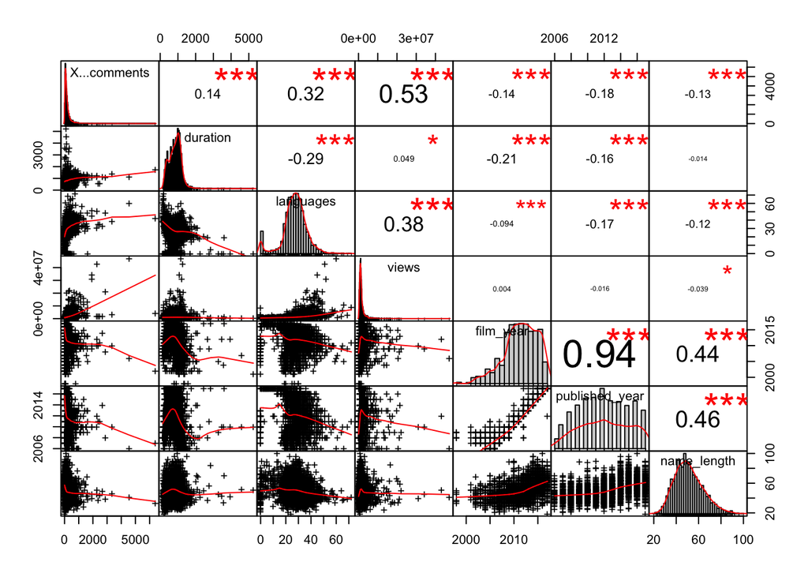

```r
suppressWarnings(chart.Correlation(subset(ted_talks[sapply(ted_talks,is.numeric)], select = -c(film_month,published_month,num_speaker) ), method = "pearson", histogram = TRUE, pch = '+'))
```

#### Conclusion

Of course these are just our observations and a large number of these conclusions are just correlations that don’t guarantee causation.